# Lab 2: Avocado Sales

Author

Sydney Thompson

Github Link: https://github.com/orsydney003/GSB_S544/tree/main/Lab2

## 0. Importing the Data Set

```python
import pandas as pd
import numpy as np
from plotnine import *

avocado_data = pd.read_csv("avocado_sales/avocado-updated-2020.csv")
avocado_data = avocado_data.reset_index(drop = True)
avocado_data
#avocado_data.head(10)
```

|  | date | average_price | total_volume | 4046 | 4225 | 4770 | total_bags | small_bags | large_bags | xlarge_bags | type | year | geography |
| --- | --- | --- | --- | --- | --- | --- | --- | --- | --- | --- | --- | --- | --- |
| 0 | 2015-01-04 | 1.22 | 40873.28 | 2819.50 | 28287.42 | 49.90 | 9716.46 | 9186.93 | 529.53 | 0.00 | conventional | 2015 | Albany |
| 1 | 2015-01-04 | 1.79 | 1373.95 | 57.42 | 153.88 | 0.00 | 1162.65 | 1162.65 | 0.00 | 0.00 | organic | 2015 | Albany |
| 2 | 2015-01-04 | 1.00 | 435021.49 | 364302.39 | 23821.16 | 82.15 | 46815.79 | 16707.15 | 30108.64 | 0.00 | conventional | 2015 | Atlanta |
| 3 | 2015-01-04 | 1.76 | 3846.69 | 1500.15 | 938.35 | 0.00 | 1408.19 | 1071.35 | 336.84 | 0.00 | organic | 2015 | Atlanta |
| 4 | 2015-01-04 | 1.08 | 788025.06 | 53987.31 | 552906.04 | 39995.03 | 141136.68 | 137146.07 | 3990.61 | 0.00 | conventional | 2015 | Baltimore/Washington |
| ... | ... | ... | ... | ... | ... | ... | ... | ... | ... | ... | ... | ... | ... |
| 33040 | 2020-11-29 | 1.47 | 1583056.27 | 67544.48 | 97996.46 | 2617.17 | 1414878.10 | 906711.52 | 480191.83 | 27974.75 | organic | 2020 | Total U.S. |
| 33041 | 2020-11-29 | 0.91 | 5811114.22 | 1352877.53 | 589061.83 | 19741.90 | 3790665.29 | 2197611.02 | 1531530.14 | 61524.13 | conventional | 2020 | West |
| 33042 | 2020-11-29 | 1.48 | 289961.27 | 13273.75 | 19341.09 | 636.51 | 256709.92 | 122606.21 | 134103.71 | 0.00 | organic | 2020 | West |
| 33043 | 2020-11-29 | 0.67 | 822818.75 | 234688.01 | 80205.15 | 10543.63 | 497381.96 | 285764.11 | 210808.02 | 809.83 | conventional | 2020 | West Tex/New Mexico |
| 33044 | 2020-11-29 | 1.35 | 24106.58 | 1236.96 | 617.80 | 1564.98 | 20686.84 | 17824.52 | 2862.32 | 0.00 | organic | 2020 | West Tex/New Mexico |

33045 rows × 13 columns

## 1. Brief Description of Data Set

For this lab, this data set contains weekly retail scan data for Hass avocados across the US from 2015-2020. This data set comes from Kaggle and the Hass Avocado Board.

There are 13 variables (columns):

- date (the date of the observation)
- average_price (the average price of a single avocado)
- type (conventional or organic) -> categorical
- year (from 2015-2020)
- geography (city/region of US of observation)
- total_volume (total number of avocados sold)
- 4046 (total number of avocados with PLU 4046 sold = small avocados)
- 4225 (total number of avocados with PLU 4225 sold = large avocados)
- 4770 (total number of avocados with PLU 4770 sold = extra large avocados)
- total_bags (total number of bags of avocados sold)
- small_bags (number of small bags of avocados sold)
- large_bags (number of large bags of avocados sold)
- xlarge_bags (number of extra-large bags of avocados sold)

## 2. Clean the data in any way you see fit.

```python
# drop Nas
avocado_data.dropna()
```

|  | date | average_price | total_volume | 4046 | 4225 | 4770 | total_bags | small_bags | large_bags | xlarge_bags | type | year | geography |
| --- | --- | --- | --- | --- | --- | --- | --- | --- | --- | --- | --- | --- | --- |
| 0 | 2015-01-04 | 1.22 | 40873.28 | 2819.50 | 28287.42 | 49.90 | 9716.46 | 9186.93 | 529.53 | 0.00 | conventional | 2015 | Albany |
| 1 | 2015-01-04 | 1.79 | 1373.95 | 57.42 | 153.88 | 0.00 | 1162.65 | 1162.65 | 0.00 | 0.00 | organic | 2015 | Albany |
| 2 | 2015-01-04 | 1.00 | 435021.49 | 364302.39 | 23821.16 | 82.15 | 46815.79 | 16707.15 | 30108.64 | 0.00 | conventional | 2015 | Atlanta |
| 3 | 2015-01-04 | 1.76 | 3846.69 | 1500.15 | 938.35 | 0.00 | 1408.19 | 1071.35 | 336.84 | 0.00 | organic | 2015 | Atlanta |
| 4 | 2015-01-04 | 1.08 | 788025.06 | 53987.31 | 552906.04 | 39995.03 | 141136.68 | 137146.07 | 3990.61 | 0.00 | conventional | 2015 | Baltimore/Washington |
| ... | ... | ... | ... | ... | ... | ... | ... | ... | ... | ... | ... | ... | ... |
| 33040 | 2020-11-29 | 1.47 | 1583056.27 | 67544.48 | 97996.46 | 2617.17 | 1414878.10 | 906711.52 | 480191.83 | 27974.75 | organic | 2020 | Total U.S. |
| 33041 | 2020-11-29 | 0.91 | 5811114.22 | 1352877.53 | 589061.83 | 19741.90 | 3790665.29 | 2197611.02 | 1531530.14 | 61524.13 | conventional | 2020 | West |
| 33042 | 2020-11-29 | 1.48 | 289961.27 | 13273.75 | 19341.09 | 636.51 | 256709.92 | 122606.21 | 134103.71 | 0.00 | organic | 2020 | West |
| 33043 | 2020-11-29 | 0.67 | 822818.75 | 234688.01 | 80205.15 | 10543.63 | 497381.96 | 285764.11 | 210808.02 | 809.83 | conventional | 2020 | West Tex/New Mexico |
| 33044 | 2020-11-29 | 1.35 | 24106.58 | 1236.96 | 617.80 | 1564.98 | 20686.84 | 17824.52 | 2862.32 | 0.00 | organic | 2020 | West Tex/New Mexico |

33045 rows × 13 columns

```python
# how many distinct regions are there? -> 54

avocado_data['geography'].unique()
```

```
array(['Albany', 'Atlanta', 'Baltimore/Washington', 'Boise', 'Boston',
       'Buffalo/Rochester', 'California', 'Charlotte', 'Chicago',
       'Cincinnati/Dayton', 'Columbus', 'Dallas/Ft. Worth', 'Denver',
       'Detroit', 'Grand Rapids', 'Great Lakes', 'Harrisburg/Scranton',
       'Hartford/Springfield', 'Houston', 'Indianapolis', 'Jacksonville',
       'Las Vegas', 'Los Angeles', 'Louisville', 'Miami/Ft. Lauderdale',
       'Midsouth', 'Nashville', 'New Orleans/Mobile', 'New York',
       'Northeast', 'Northern New England', 'Orlando', 'Philadelphia',
       'Phoenix/Tucson', 'Pittsburgh', 'Plains', 'Portland',
       'Raleigh/Greensboro', 'Richmond/Norfolk', 'Roanoke', 'Sacramento',
       'San Diego', 'San Francisco', 'Seattle', 'South Carolina',
       'South Central', 'Southeast', 'Spokane', 'St. Louis', 'Syracuse',
       'Tampa', 'Total U.S.', 'West', 'West Tex/New Mexico'], dtype=object)
```

```python
# rename columns 4046, 4225, and 4770

avocado_data = avocado_data.rename(columns = {'4046': 'sm_avocados_plu_4046', '4225': 'lg_avocados_plu_4225', '4770': 'xl_avocados_plu_4770'})
avocado_data
```

|  | date | average_price | total_volume | sm_avocados_plu_4046 | lg_avocados_plu_4225 | xl_avocados_plu_4770 | total_bags | small_bags | large_bags | xlarge_bags | type | year | geography |
| --- | --- | --- | --- | --- | --- | --- | --- | --- | --- | --- | --- | --- | --- |
| 0 | 2015-01-04 | 1.22 | 40873.28 | 2819.50 | 28287.42 | 49.90 | 9716.46 | 9186.93 | 529.53 | 0.00 | conventional | 2015 | Albany |
| 1 | 2015-01-04 | 1.79 | 1373.95 | 57.42 | 153.88 | 0.00 | 1162.65 | 1162.65 | 0.00 | 0.00 | organic | 2015 | Albany |
| 2 | 2015-01-04 | 1.00 | 435021.49 | 364302.39 | 23821.16 | 82.15 | 46815.79 | 16707.15 | 30108.64 | 0.00 | conventional | 2015 | Atlanta |
| 3 | 2015-01-04 | 1.76 | 3846.69 | 1500.15 | 938.35 | 0.00 | 1408.19 | 1071.35 | 336.84 | 0.00 | organic | 2015 | Atlanta |
| 4 | 2015-01-04 | 1.08 | 788025.06 | 53987.31 | 552906.04 | 39995.03 | 141136.68 | 137146.07 | 3990.61 | 0.00 | conventional | 2015 | Baltimore/Washington |
| ... | ... | ... | ... | ... | ... | ... | ... | ... | ... | ... | ... | ... | ... |
| 33040 | 2020-11-29 | 1.47 | 1583056.27 | 67544.48 | 97996.46 | 2617.17 | 1414878.10 | 906711.52 | 480191.83 | 27974.75 | organic | 2020 | Total U.S. |
| 33041 | 2020-11-29 | 0.91 | 5811114.22 | 1352877.53 | 589061.83 | 19741.90 | 3790665.29 | 2197611.02 | 1531530.14 | 61524.13 | conventional | 2020 | West |
| 33042 | 2020-11-29 | 1.48 | 289961.27 | 13273.75 | 19341.09 | 636.51 | 256709.92 | 122606.21 | 134103.71 | 0.00 | organic | 2020 | West |
| 33043 | 2020-11-29 | 0.67 | 822818.75 | 234688.01 | 80205.15 | 10543.63 | 497381.96 | 285764.11 | 210808.02 | 809.83 | conventional | 2020 | West Tex/New Mexico |
| 33044 | 2020-11-29 | 1.35 | 24106.58 | 1236.96 | 617.80 | 1564.98 | 20686.84 | 17824.52 | 2862.32 | 0.00 | organic | 2020 | West Tex/New Mexico |

33045 rows × 13 columns

```python
# geography variable is categorized either as a city -> state -> region -> US (total US)

# splitting into the 8 major regions: Great Lakes, Midsouth, Northeast,
# Northern New England, Plains, South Central, Southeast, West
# leave individual cities alone

# Splitting into the 8 major regions:
# Great Lakes, Midsouth, Northeast, Northern New England,
# Plains, South Central, Southeast, West

major_region = {
    # Northeast
    "Albany": "Northeast",
    "Baltimore/Washington": "Northeast",
    "Boston": "Northeast",
    "Buffalo/Rochester": "Northeast",
    "Harrisburg/Scranton": "Northeast",
    "Hartford/Springfield": "Northeast",
    "New York": "Northeast",
    "Philadelphia": "Northeast",
    "Pittsburgh": "Northeast",
    "Syracuse": "Northeast",
    "Northeast": "Northeast",

    # Northern New England
    "Northern New England": "Northern New England",

    # Great Lakes
    "Chicago": "Great Lakes",
    "Cincinnati/Dayton": "Great Lakes",
    "Columbus": "Great Lakes",
    "Detroit": "Great Lakes",
    "Grand Rapids": "Great Lakes",
    "Indianapolis": "Great Lakes",
    "Great Lakes": "Great Lakes",

    # Midsouth
    "Louisville": "Midsouth",
    "Nashville": "Midsouth",
    "Midsouth": "Midsouth",

    # Plains
    "St. Louis": "Plains",
    "Plains": "Plains",

    # South Central
    "Dallas/Ft. Worth": "South Central",
    "Houston": "South Central",
    "South Central": "South Central",

    # Southeast
    "Atlanta": "Southeast",
    "Charlotte": "Southeast",
    "Jacksonville": "Southeast",
    "Miami/Ft. Lauderdale": "Southeast",
    "Orlando": "Southeast",
    "Raleigh/Greensboro": "Southeast",
    "Richmond/Norfolk": "Southeast",
    "Roanoke": "Southeast",
    "South Carolina": "Southeast",
    "Tampa": "Southeast",
    "New Orleans/Mobile": "Southeast",
    "Southeast": "Southeast",

    # West
    "Boise": "West",
    "California": "West",
    "Denver": "West",
    "Las Vegas": "West",
    "Los Angeles": "West",
    "Phoenix/Tucson": "West",
    "Portland": "West",
    "Sacramento": "West",
    "San Diego": "West",
    "San Francisco": "West",
    "Seattle": "West",
    "Spokane": "West",
    "West Tex/New Mexico": "West",
    "West": "West",
}

avocado_data['major_region'] = avocado_data['geography'].map(major_region)
avocado_data.dropna()
avocado_data
```

|  | date | average_price | total_volume | sm_avocados_plu_4046 | lg_avocados_plu_4225 | xl_avocados_plu_4770 | total_bags | small_bags | large_bags | xlarge_bags | type | year | geography | major_region |
| --- | --- | --- | --- | --- | --- | --- | --- | --- | --- | --- | --- | --- | --- | --- |
| 0 | 2015-01-04 | 1.22 | 40873.28 | 2819.50 | 28287.42 | 49.90 | 9716.46 | 9186.93 | 529.53 | 0.00 | conventional | 2015 | Albany | Northeast |
| 1 | 2015-01-04 | 1.79 | 1373.95 | 57.42 | 153.88 | 0.00 | 1162.65 | 1162.65 | 0.00 | 0.00 | organic | 2015 | Albany | Northeast |
| 2 | 2015-01-04 | 1.00 | 435021.49 | 364302.39 | 23821.16 | 82.15 | 46815.79 | 16707.15 | 30108.64 | 0.00 | conventional | 2015 | Atlanta | Southeast |
| 3 | 2015-01-04 | 1.76 | 3846.69 | 1500.15 | 938.35 | 0.00 | 1408.19 | 1071.35 | 336.84 | 0.00 | organic | 2015 | Atlanta | Southeast |
| 4 | 2015-01-04 | 1.08 | 788025.06 | 53987.31 | 552906.04 | 39995.03 | 141136.68 | 137146.07 | 3990.61 | 0.00 | conventional | 2015 | Baltimore/Washington | Northeast |
| ... | ... | ... | ... | ... | ... | ... | ... | ... | ... | ... | ... | ... | ... | ... |
| 33040 | 2020-11-29 | 1.47 | 1583056.27 | 67544.48 | 97996.46 | 2617.17 | 1414878.10 | 906711.52 | 480191.83 | 27974.75 | organic | 2020 | Total U.S. | NaN |
| 33041 | 2020-11-29 | 0.91 | 5811114.22 | 1352877.53 | 589061.83 | 19741.90 | 3790665.29 | 2197611.02 | 1531530.14 | 61524.13 | conventional | 2020 | West | West |
| 33042 | 2020-11-29 | 1.48 | 289961.27 | 13273.75 | 19341.09 | 636.51 | 256709.92 | 122606.21 | 134103.71 | 0.00 | organic | 2020 | West | West |
| 33043 | 2020-11-29 | 0.67 | 822818.75 | 234688.01 | 80205.15 | 10543.63 | 497381.96 | 285764.11 | 210808.02 | 809.83 | conventional | 2020 | West Tex/New Mexico | West |
| 33044 | 2020-11-29 | 1.35 | 24106.58 | 1236.96 | 617.80 | 1564.98 | 20686.84 | 17824.52 | 2862.32 | 0.00 | organic | 2020 | West Tex/New Mexico | West |

33045 rows × 14 columns

```python
# cleaning for metro regions

metro_regions = ['Albany', 'Atlanta', 'Baltimore/Washington', 'Boise', 'Boston',
       'Buffalo/Rochester', 'Charlotte', 'Chicago',
       'Cincinnati/Dayton', 'Columbus', 'Dallas/Ft. Worth', 'Denver',
       'Detroit', 'Grand Rapids', 'Harrisburg/Scranton',
       'Hartford/Springfield', 'Houston', 'Indianapolis', 'Jacksonville',
       'Las Vegas', 'Los Angeles', 'Louisville', 'Miami/Ft. Lauderdale',
       'Nashville', 'New Orleans/Mobile', 'New York',
       'Orlando', 'Philadelphia', 'Phoenix/Tucson', 'Pittsburgh', 'Portland',
       'Raleigh/Greensboro', 'Richmond/Norfolk', 'Roanoke', 'Sacramento',
       'San Diego', 'San Francisco', 'Seattle', 'Spokane',
       'St. Louis', 'Syracuse', 'Tampa']

# using .loc and .isin() to create the 'metro_regions'
avocado_data['metro_regions'] = np.nan
avocado_data.loc[avocado_data['geography'].isin(metro_regions), 'metro_regions'] = avocado_data['geography']

#avocado_data
```

## 3. Which major geographical region sold the most total organic, small Hass avocados in 2017?

```python
#3. Which major geographical region sold the most total organic, small Hass avocados in 2017?

avocado_clean = avocado_data

avocado_clean = avocado_clean[(avocado_clean['year'] == 2017) & (avocado_clean['type'] == 'organic')]
avocado_clean

avocado_clean[["sm_avocados_plu_4046", "major_region"]]
avocado_clean.groupby('major_region')['sm_avocados_plu_4046'].sum()

# west is the most
```

```
major_region
Great Lakes              300229.36
Midsouth                 197683.66
Northeast               1850146.84
Northern New England       1249.48
Plains                   213955.55
South Central           2588326.02
Southeast                545625.88
West                    5826061.33
Name: sm_avocados_plu_4046, dtype: float64
```

The `West` region sold the most total organic, small Hass avocados in 2017. This region sold approximately 5,826,061 small, organic Hass avocados that year.

## 4. Split the `date` variable into month, day, and year variables. In which month is the highest average volume of avocado sales?

```python
# 4. Split the date variable into month, day, and year variables.

avocado_clean2 = avocado_data

avocado_clean2['date'] = pd.to_datetime(avocado_clean2['date'])

avocado_clean2['month'] = avocado_clean2['date'].dt.month
avocado_clean2['day'] = avocado_clean2['date'].dt.day

#avocado_clean2
```

```python
# groupby month and calculate average total_volume
average_volume_by_month = avocado_clean2.groupby('month')['total_volume'].mean()
average_volume_by_month
```

```
month
1     9.853122e+05
2     1.095374e+06
3     9.957150e+05
4     1.016582e+06
5     1.123632e+06
6     1.051247e+06
7     9.832681e+05
8     9.499249e+05
9     9.064773e+05
10    8.446863e+05
11    8.223470e+05
12    8.076695e+05
Name: total_volume, dtype: float64
```

```python
# Find the month with the highest average volume
month_highest_volume = average_volume_by_month.sort_values(ascending=False)
month_highest_volume

# may is the highest month
```

```
month
5     1.123632e+06
2     1.095374e+06
6     1.051247e+06
4     1.016582e+06
3     9.957150e+05
1     9.853122e+05
7     9.832681e+05
8     9.499249e+05
9     9.064773e+05
10    8.446863e+05
11    8.223470e+05
12    8.076695e+05
Name: total_volume, dtype: float64
```

As a result, May is the month with the highest average volume of avocado sales with 1,123,632 avocados sold.

## 5. Which metro area geographical regions sold the most total avocados? Plot the side-by-side box-plots of the total volume for only the five metro geographical regions with the highest averages for the total_volume variable.

```python
avocado_clean3 = avocado_data
avocado_clean3 = avocado_clean3[avocado_clean3['metro_regions'].notna()]
avocado_clean3

avocado_clean3 = avocado_clean3.groupby('metro_regions')['total_volume'].sum().reset_index()
avocado_clean3 = avocado_clean3.sort_values(by='total_volume', ascending=False)

# looked up nlargest() to get top 5 metro regions by total volume
top_5_clean = avocado_clean3.nlargest(5, 'total_volume')
top_5_clean
```

|  | metro_regions | total_volume |
| --- | --- | --- |
| 20 | Los Angeles | 9.593505e+08 |
| 25 | New York | 5.282452e+08 |
| 10 | Dallas/Ft. Worth | 4.362042e+08 |
| 16 | Houston | 4.208438e+08 |
| 28 | Phoenix/Tucson | 3.825234e+08 |

```python
# summary statistics
top_5_clean.describe()
```

|  | total_volume |
| --- | --- |
| count | 5.000000e+00 |
| mean | 5.454334e+08 |
| std | 2.374953e+08 |
| min | 3.825234e+08 |
| 25% | 4.208438e+08 |
| 50% | 4.362042e+08 |
| 75% | 5.282452e+08 |
| max | 9.593505e+08 |

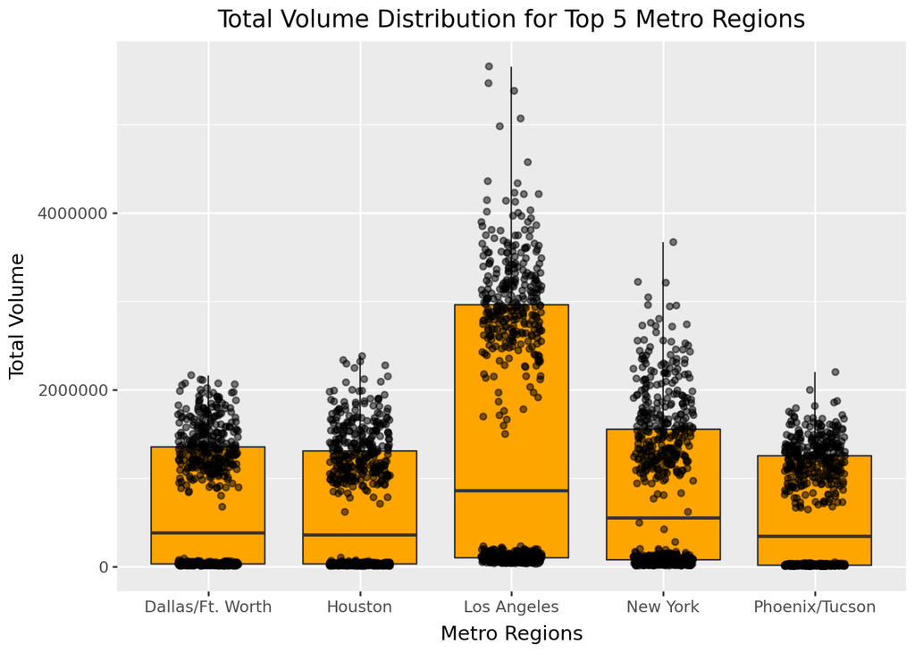

```python
from plotnine import *

# Filter the original avocado_clean data to include only the top 5 metro regions
top_5_regions_list = top_5_clean['metro_regions'].tolist()
avocado_top_5_regions = avocado_data[avocado_data['metro_regions'].isin(top_5_regions_list)]

(ggplot(avocado_top_5_regions, aes(x='metro_regions', y='total_volume'))
 + geom_boxplot(fill = "orange")
 # geom_jitter() allows to see individual observations
 + geom_jitter(width=0.2, alpha=0.5)
 + labs(x='Metro Regions', y='Total Volume', title = "Total Volume Distribution for Top 5 Metro Regions"))
```

The top 5 metro regions that sold the most total avocados were Los Angeles, New York, Dallas/Ft. Worth, Houston, and Phoenix/Tucson. The highest average values were plotted in the box-plot above. Los Angeles’ average was 1,567,566 avocados sold; New York’s average was 863,145.8 avocados sold; Dallas/Ft. Worth’s average was 712,751.9 avocados sold; Houston’s average was 687,653.3 avocados sold; finally, Phoenix/Tucson’s average was 625,038.3 avocados sold.

In addition, the total volume of avocados sold in Los Angeles was 959,350,500. For New York, it was 528,245,200 avocados sold. For Dallas/Ft. Worth, the total volume was 436,204,200 avocados sold. For Houston, it was 420,843,800 avocados sold. Finally, for Phoenix/Tucson, the total volume was 382,523,400 avocados sold.

## 6. From your cleaned data set, create a data set with only these California regions and answer the following questions about these California regions only.

```python
avocado_clean4 = avocado_data

avocado_clean4 = avocado_clean4[((avocado_clean4['geography'] == 'San Diego') | (avocado_clean4['geography'] == 'Los Angeles') | (avocado_clean4['geography'] == 'San Francisco') | (avocado_clean4['geography'] == 'Sacramento'))]
avocado_clean4
```

|  | date | average_price | total_volume | sm_avocados_plu_4046 | lg_avocados_plu_4225 | xl_avocados_plu_4770 | total_bags | small_bags | large_bags | xlarge_bags | type | year | geography | major_region | metro_regions | month | day |
| --- | --- | --- | --- | --- | --- | --- | --- | --- | --- | --- | --- | --- | --- | --- | --- | --- | --- |
| 44 | 2015-01-04 | 0.85 | 2682159.95 | 1837999.65 | 524430.47 | 64225.78 | 255504.05 | 215571.80 | 36981.72 | 2950.53 | conventional | 2015 | Los Angeles | West | Los Angeles | 1 | 4 |
| 45 | 2015-01-04 | 1.25 | 54495.54 | 47721.51 | 1723.40 | 0.00 | 5050.63 | 5050.63 | 0.00 | 0.00 | organic | 2015 | Los Angeles | West | Los Angeles | 1 | 4 |
| 80 | 2015-01-04 | 1.05 | 430138.88 | 110693.69 | 270107.61 | 9737.50 | 39600.08 | 39600.08 | 0.00 | 0.00 | conventional | 2015 | Sacramento | West | Sacramento | 1 | 4 |
| 81 | 2015-01-04 | 1.33 | 9213.49 | 3727.52 | 4327.52 | 0.00 | 1158.45 | 1158.45 | 0.00 | 0.00 | organic | 2015 | Sacramento | West | Sacramento | 1 | 4 |
| 82 | 2015-01-04 | 0.94 | 461607.33 | 244152.26 | 165299.33 | 15302.75 | 36852.99 | 30884.29 | 5595.00 | 373.70 | conventional | 2015 | San Diego | West | San Diego | 1 | 4 |
| ... | ... | ... | ... | ... | ... | ... | ... | ... | ... | ... | ... | ... | ... | ... | ... | ... | ... |
| 33018 | 2020-11-29 | 1.43 | 23531.38 | 3303.69 | 2057.03 | 0.00 | 18170.66 | 18144.54 | 26.12 | 0.00 | organic | 2020 | Sacramento | West | Sacramento | 11 | 29 |
| 33019 | 2020-11-29 | 1.12 | 469356.72 | 104509.99 | 19988.45 | 7210.47 | 337647.81 | 189341.36 | 127701.64 | 20604.81 | conventional | 2020 | San Diego | West | San Diego | 11 | 29 |
| 33020 | 2020-11-29 | 1.95 | 25799.95 | 894.63 | 838.11 | 0.00 | 24067.21 | 9691.46 | 14375.75 | 0.00 | organic | 2020 | San Diego | West | San Diego | 11 | 29 |
| 33021 | 2020-11-29 | 1.50 | 644141.37 | 128555.43 | 136718.24 | 5597.21 | 373270.49 | 159276.65 | 207760.32 | 6233.52 | conventional | 2020 | San Francisco | West | San Francisco | 11 | 29 |
| 33022 | 2020-11-29 | 1.87 | 59527.02 | 2815.23 | 4542.30 | 0.00 | 52169.49 | 52034.33 | 135.16 | 0.00 | organic | 2020 | San Francisco | West | San Francisco | 11 | 29 |

2448 rows × 17 columns

## 7. In which California regions is the price of organic versus conventional avocados most different? Support your answer with a few summary statistics AND a visualization.

```python
# average price for conventional and organic avocados in the CA regions
california_avg_price = avocado_clean4.groupby(['geography', 'type'])['average_price'].mean()

# Unstack the 'type' level to make 'conventional' and 'organic' into columns
california_avg_price_unstacked = california_avg_price.unstack()

# price difference between organic and conventional avocados
california_avg_price_unstacked['price_difference'] = abs(california_avg_price_unstacked['organic'] - california_avg_price_unstacked['conventional'])

california_avg_price_unstacked
```

| type geography | conventional | organic | price_difference |
| --- | --- | --- | --- |
| Los Angeles | 1.047124 | 1.574902 | 0.527778 |
| Sacramento | 1.295359 | 1.873856 | 0.578497 |
| San Diego | 1.113856 | 1.798366 | 0.684510 |
| San Francisco | 1.400490 | 2.119444 | 0.718954 |

```python
# summary statistics
california_avg_price_unstacked.describe()
```

| type | conventional | organic | price_difference |
| --- | --- | --- | --- |
| count | 4.000000 | 4.000000 | 4.000000 |
| mean | 1.214208 | 1.841642 | 0.627435 |
| std | 0.162557 | 0.224525 | 0.089368 |
| min | 1.047124 | 1.574902 | 0.527778 |
| 25% | 1.097173 | 1.742500 | 0.565817 |
| 50% | 1.204608 | 1.836111 | 0.631503 |
| 75% | 1.321642 | 1.935253 | 0.693121 |
| max | 1.400490 | 2.119444 | 0.718954 |

```python
# find region with largest price difference
region_most_different = california_avg_price_unstacked['price_difference'].sort_values(ascending=False)
region_most_different
```

```
geography
San Francisco    0.718954
San Diego        0.684510
Sacramento       0.578497
Los Angeles      0.527778
Name: price_difference, dtype: float64
```

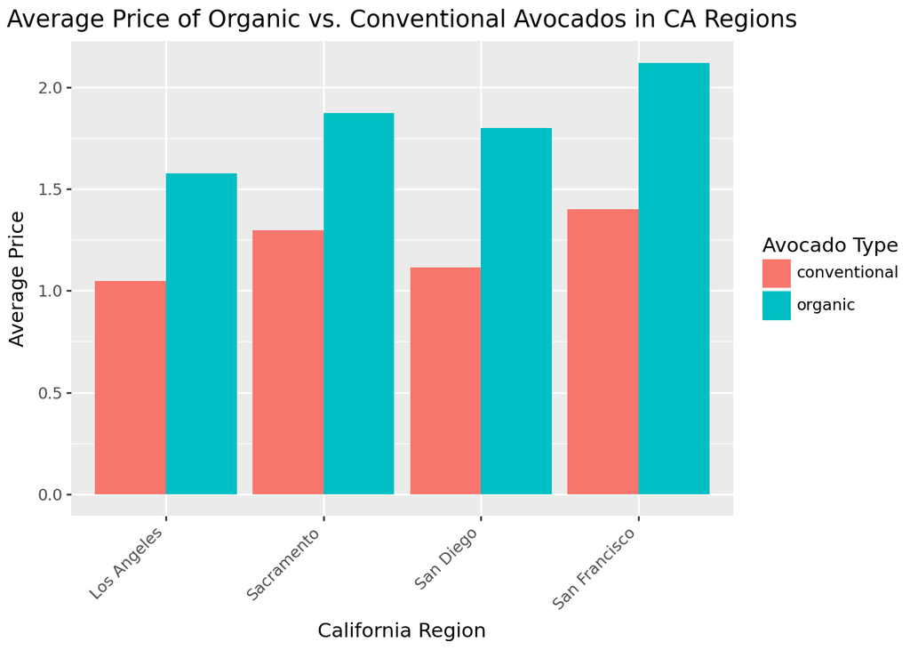

```python
# summary plot showing differences between cities in CA

from plotnine import *

# using .melt() and reseting index to reshape data set
california_avg_price_melted = california_avg_price_unstacked.reset_index().melt(id_vars='geography', value_vars=['conventional', 'organic'], var_name='type', value_name='average_price')

# visualization: bar chart
(ggplot(california_avg_price_melted, aes(x='geography', y='average_price', fill='type'))
 + geom_bar(stat='identity', position='dodge')
 + labs(x='California Region', y='Average Price', fill='Avocado Type',
        title='Average Price of Organic vs. Conventional Avocados in CA Regions')
 + theme(axis_text_x=element_text(rotation=45, hjust=1)))
```

Based on my summary statistics, tables, and bar chart, San Francisco has the highest price difference between organic and conventional avocados. The price difference for San Francisco is $0.72. For San Diego, it is $0.68. For Sacramento, it is $0.58. Finally, the price difference for Los Angeles is $0.53.

```python
# first transforming data

ca_prop = avocado_clean4
ca_prop
```

|  | date | average_price | total_volume | sm_avocados_plu_4046 | lg_avocados_plu_4225 | xl_avocados_plu_4770 | total_bags | small_bags | large_bags | xlarge_bags | type | year | geography | major_region | metro_regions | month | day |
| --- | --- | --- | --- | --- | --- | --- | --- | --- | --- | --- | --- | --- | --- | --- | --- | --- | --- |
| 44 | 2015-01-04 | 0.85 | 2682159.95 | 1837999.65 | 524430.47 | 64225.78 | 255504.05 | 215571.80 | 36981.72 | 2950.53 | conventional | 2015 | Los Angeles | West | Los Angeles | 1 | 4 |
| 45 | 2015-01-04 | 1.25 | 54495.54 | 47721.51 | 1723.40 | 0.00 | 5050.63 | 5050.63 | 0.00 | 0.00 | organic | 2015 | Los Angeles | West | Los Angeles | 1 | 4 |
| 80 | 2015-01-04 | 1.05 | 430138.88 | 110693.69 | 270107.61 | 9737.50 | 39600.08 | 39600.08 | 0.00 | 0.00 | conventional | 2015 | Sacramento | West | Sacramento | 1 | 4 |
| 81 | 2015-01-04 | 1.33 | 9213.49 | 3727.52 | 4327.52 | 0.00 | 1158.45 | 1158.45 | 0.00 | 0.00 | organic | 2015 | Sacramento | West | Sacramento | 1 | 4 |
| 82 | 2015-01-04 | 0.94 | 461607.33 | 244152.26 | 165299.33 | 15302.75 | 36852.99 | 30884.29 | 5595.00 | 373.70 | conventional | 2015 | San Diego | West | San Diego | 1 | 4 |
| ... | ... | ... | ... | ... | ... | ... | ... | ... | ... | ... | ... | ... | ... | ... | ... | ... | ... |
| 33018 | 2020-11-29 | 1.43 | 23531.38 | 3303.69 | 2057.03 | 0.00 | 18170.66 | 18144.54 | 26.12 | 0.00 | organic | 2020 | Sacramento | West | Sacramento | 11 | 29 |
| 33019 | 2020-11-29 | 1.12 | 469356.72 | 104509.99 | 19988.45 | 7210.47 | 337647.81 | 189341.36 | 127701.64 | 20604.81 | conventional | 2020 | San Diego | West | San Diego | 11 | 29 |
| 33020 | 2020-11-29 | 1.95 | 25799.95 | 894.63 | 838.11 | 0.00 | 24067.21 | 9691.46 | 14375.75 | 0.00 | organic | 2020 | San Diego | West | San Diego | 11 | 29 |
| 33021 | 2020-11-29 | 1.50 | 644141.37 | 128555.43 | 136718.24 | 5597.21 | 373270.49 | 159276.65 | 207760.32 | 6233.52 | conventional | 2020 | San Francisco | West | San Francisco | 11 | 29 |
| 33022 | 2020-11-29 | 1.87 | 59527.02 | 2815.23 | 4542.30 | 0.00 | 52169.49 | 52034.33 | 135.16 | 0.00 | organic | 2020 | San Francisco | West | San Francisco | 11 | 29 |

2448 rows × 17 columns

```python
ca_regions = ["Los Angeles", "Sacramento", "San Diego", "San Francisco"]
geo_order = ca_regions
type_order = ["conventional", "organic"]
size_order = ["Xlarge", "Large", "Small"]

size_colors = {
    "Small": "#E7791D",
    "Large": "#25A18E",
    "Xlarge": "#7765B2"
    }

# fixed percent axis (no lambdas)
breaks_pct = [0, 0.25, 0.50, 0.75, 1.00]
labels_pct = ["0%", "25%", "50%", "75%", "100%"]
```

```python
# map sizes with .merge()
size_map_df = pd.DataFrame({
    "avocado_size": ["sm_avocados_plu_4046", "lg_avocados_plu_4225", "xl_avocados_plu_4770"],
    "size": ["Small", "Large", "Xlarge"]
})
```

```python
# changing from wide to long format
# also check ca_regions and compute mean for geography and type

ca_wide = (
    avocado_clean4.loc[avocado_clean4["geography"].isin(ca_regions)]
            .groupby(["geography", "type"], as_index=False)[
                ["sm_avocados_plu_4046", "lg_avocados_plu_4225", "xl_avocados_plu_4770"]
            ].mean()
)

# long format
ca_long = (
    ca_wide.melt(id_vars=["geography", "type"],
                 var_name="avocado_size",
                 value_name="volume")
          .merge(size_map_df, on="avocado_size", how="left")
)
```

```python
# sum by (geography, type, size) then proportions within each (geography, type)
ca = (ca_long.groupby(["geography", "type", "size"], as_index=False)["volume"].sum())
group_totals = ca.groupby(["geography", "type"])["volume"].transform("sum")  # no lambda
ca["proportion"] = ca["volume"] / group_totals

# 4) factor orders (controls x order and stack order)
ca["geography"] = pd.Categorical(ca["geography"], geo_order, ordered=True)
ca["type"] = pd.Categorical(ca["type"], type_order, ordered=True)
ca["size"] = pd.Categorical(ca["size"], size_order, ordered=True)
```

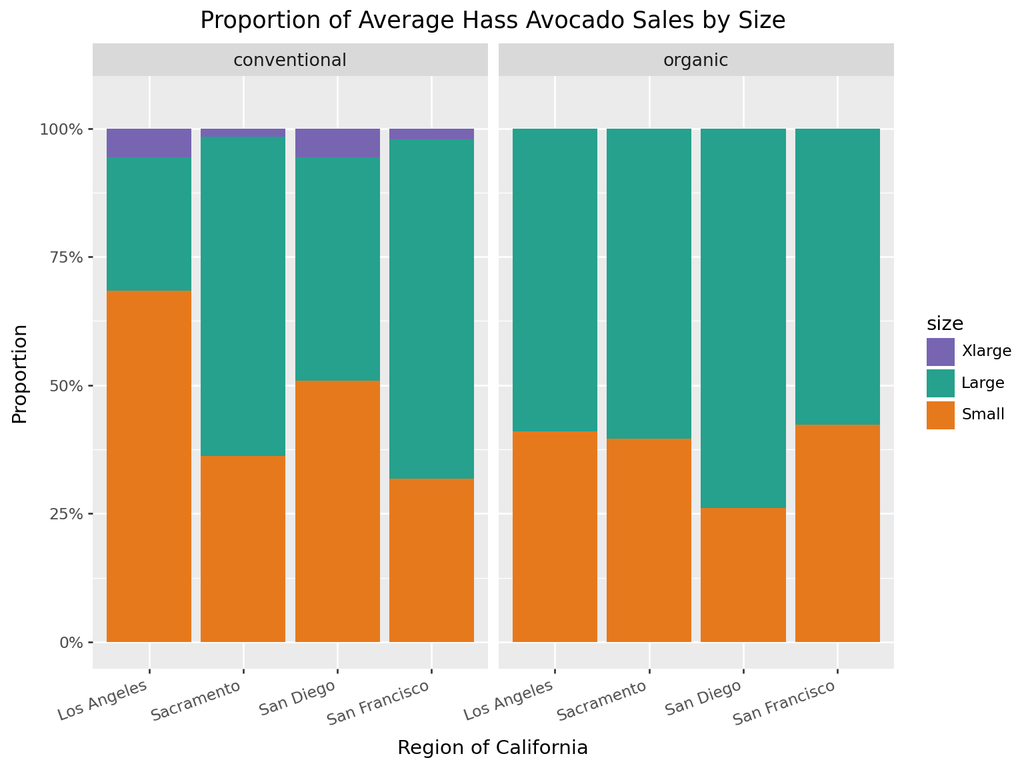

```python
# recreating the plot

(
    ggplot(ca, aes("geography", "proportion", fill="size"))
    + geom_col()
    + facet_wrap("~type", ncol=2)
    + scale_y_continuous(breaks=breaks_pct, labels=labels_pct)
    + coord_cartesian(ylim=(0, 1.05))
    + scale_fill_manual(values=size_colors, limits=size_order, name="size")
    + labs(title="Proportion of Average Hass Avocado Sales by Size",
           x="Region of California", y="Proportion")
    + theme(axis_text_x=element_text(rotation=20, hjust=1),
            strip_text=element_text(size=10),
            figure_size=(8, 6))
)
```

## Outside Data: A joke in the media is that Millennials can’t afford houses, because they spend all their money buying avocado toast. Let’s use this data set to address that claim. Find or assemble a data set of real data, with house prices for these four California regions. Join this data set with your California avocado data set. Use your new joined data set to make an argument about the relationship between house prices and avocado prices/sales. Support your argument with a plot.

```python
# outside data

import pandas as pd
from plotnine import *

# reading in zillow .csv file from internet
# under zillow housing data sets
# https://www.zillow.com/research/data/?msockid=12cdad0ca6f56dac19abbb68a7836c03

zillow_url = "https://files.zillowstatic.com/research/public_csvs/zhvi/Metro_zhvi_uc_sfrcondo_tier_0.33_0.67_sm_sa_month.csv"
zillow_df = pd.read_csv(zillow_url)
zillow_df
```

|  | RegionID | SizeRank | RegionName | RegionType | StateName | 2000-01-31 | 2000-02-29 | 2000-03-31 | 2000-04-30 | 2000-05-31 | ... | 2024-11-30 | 2024-12-31 | 2025-01-31 | 2025-02-28 | 2025-03-31 | 2025-04-30 | 2025-05-31 | 2025-06-30 | 2025-07-31 | 2025-08-31 |
| --- | --- | --- | --- | --- | --- | --- | --- | --- | --- | --- | --- | --- | --- | --- | --- | --- | --- | --- | --- | --- | --- |
| 0 | 102001 | 0 | United States | country | NaN | 123266.200632 | 123483.065395 | 123752.009633 | 124328.842231 | 124992.707395 | ... | 364462.357353 | 365188.640378 | 365823.798029 | 366287.152111 | 366009.670511 | 365477.500729 | 364786.658389 | 364164.687570 | 363734.792944 | 363505.418222 |
| 1 | 394913 | 1 | New York, NY | msa | NY | 220834.762563 | 221773.185705 | 222720.300336 | 224639.521066 | 226626.940595 | ... | 690755.304890 | 692575.728852 | 693669.194915 | 694977.328807 | 696695.225717 | 699159.431275 | 700949.662026 | 702443.165533 | 703629.915468 | 704429.490778 |
| 2 | 753899 | 2 | Los Angeles, CA | msa | CA | 222015.511375 | 222841.690769 | 223942.153841 | 226131.705683 | 228526.388970 | ... | 961498.007841 | 965544.021513 | 966083.013802 | 964049.558192 | 958942.953993 | 954617.341638 | 949834.733548 | 945472.000401 | 942874.715529 | 941801.259283 |
| 3 | 394463 | 3 | Chicago, IL | msa | IL | 156057.927247 | 156202.391427 | 156477.526001 | 157161.992446 | 157985.323252 | ... | 331806.815527 | 333077.217269 | 334445.324061 | 335814.963432 | 336675.321538 | 337286.526381 | 337582.082090 | 337949.183099 | 338802.799156 | 339815.521916 |
| 4 | 394514 | 4 | Dallas, TX | msa | TX | 128589.525231 | 128646.799455 | 128712.642038 | 128883.628311 | 129109.069031 | ... | 379351.516745 | 378817.350669 | 378284.400353 | 377491.069116 | 375977.244491 | 373834.225962 | 371400.003667 | 369018.279864 | 366986.526298 | 365614.233164 |
| ... | ... | ... | ... | ... | ... | ... | ... | ... | ... | ... | ... | ... | ... | ... | ... | ... | ... | ... | ... | ... | ... |
| 890 | 753929 | 935 | Zapata, TX | msa | TX | NaN | NaN | NaN | NaN | NaN | ... | 143283.292837 | 142658.959908 | 142159.206498 | 141618.441384 | 140840.700521 | 138617.669077 | 136190.680247 | 133897.666875 | 133120.384127 | 132635.651369 |
| 891 | 394743 | 936 | Ketchikan, AK | msa | AK | NaN | NaN | NaN | NaN | NaN | ... | 371111.566446 | 371477.951347 | 371938.983696 | 373130.833280 | 373913.842325 | 375590.069235 | 378634.099924 | 382809.172174 | 386989.733579 | 391314.961140 |
| 892 | 753874 | 937 | Craig, CO | msa | CO | 100444.259567 | 100701.102563 | 101179.276939 | 101860.241419 | 102651.568759 | ... | 296613.490364 | 297692.314312 | 297979.028774 | 298763.390664 | 299086.202973 | 300382.348633 | 301798.759660 | 302876.488509 | 304048.071855 | 305078.582927 |
| 893 | 395188 | 938 | Vernon, TX | msa | TX | NaN | NaN | NaN | NaN | NaN | ... | 107979.417830 | 106403.166626 | 105252.734042 | 104204.134361 | 102964.733167 | 101419.886599 | 100175.767132 | 99266.081766 | 98632.513599 | 98358.943635 |
| 894 | 394767 | 939 | Lamesa, TX | msa | TX | NaN | NaN | NaN | NaN | NaN | ... | 105217.532781 | 104853.504928 | 104176.477548 | 104529.062230 | 104971.547252 | 105292.523768 | 105158.796178 | 105024.154726 | 105017.335185 | 104772.899426 |

895 rows × 313 columns

```python
# keeping and renaming for the 4 cities
metros_keep = {
    "Los Angeles, CA": "Los Angeles",
    "San Diego, CA": "San Diego",
    "Sacramento, CA": "Sacramento",
    "San Francisco, CA": "San Francisco",
}

# using the dataframe from above and mapping to metro_keep (dictionary)
zillow_df = (zillow_df[zillow_df["RegionName"].isin(metros_keep.keys())])
zillow_df["geography"] = zillow_df["RegionName"].map(metros_keep)

date_columns = zillow_df.columns[5:]

# .melt() from wide to long format of dataset
# zhvi -> stands for Zillow Home Value Index
# in data set, the prices are shown under different dates (from 2000-2025)
zillow_long = (
    zillow_df.melt(id_vars=["geography","RegionName","StateName","RegionID"],
               value_vars=date_columns,
               var_name="date", value_name="zhvi_usd")
)
zillow_long["date"] = pd.to_datetime(zillow_long["date"])
zillow_long["year"] = zillow_long["date"].dt.year

# annual typical home value by metro-year
zillow_year = (
    zillow_long.groupby(["geography","year"], as_index=False)["zhvi_usd"].mean()
)
```

```python
# filtering for date, geography, type, year
# using clean_6 dataset and assigning it to new variable

df_zillow = avocado_clean4
df_zillow["date"] = pd.to_datetime(df_zillow["date"])

# isin() to check that both of these are in the data set
df_zillow = df_zillow[df_zillow["geography"].isin(["Los Angeles",
                                                   "San Diego",
                                                   "Sacramento",
                                                   "San Francisco"])]

df_zillow["year"] = df_zillow["date"].dt.year

# annual summaries for geography, type, and year
# used groupby and aggregate functions
avo_year = (
    df_zillow.groupby(["geography", "type", "year"], as_index=False)
      .agg(avg_avocado_price=("average_price", "mean"),
           total_volume=("total_volume", "sum"))
)

#avo_year
```

```python
# merging the two datasets
joined_data = avo_year.merge(zillow_year, on=["geography","year"], how="inner")
joined_data

# sorting based on geography variable
joined_data.sort_values(by='geography', ascending=False).reset_index(drop=True)
```

|  | geography | type | year | avg_avocado_price | total_volume | zhvi_usd |
| --- | --- | --- | --- | --- | --- | --- |
| 0 | San Francisco | organic | 2020 | 1.965833 | 3.279171e+06 | 943111.130995 |
| 1 | San Francisco | conventional | 2020 | 1.372083 | 4.959402e+07 | 943111.130995 |
| 2 | San Francisco | conventional | 2015 | 1.299423 | 3.827002e+07 | 703247.476650 |
| 3 | San Francisco | conventional | 2017 | 1.528679 | 4.082513e+07 | 819690.896079 |
| 4 | San Francisco | conventional | 2018 | 1.315510 | 4.761969e+07 | 907462.464776 |
| 5 | San Francisco | conventional | 2019 | 1.469231 | 4.710290e+07 | 915202.435389 |
| 6 | San Francisco | conventional | 2016 | 1.408462 | 4.029172e+07 | 773235.378937 |
| 7 | San Francisco | organic | 2015 | 1.942692 | 1.175778e+06 | 703247.476650 |
| 8 | San Francisco | organic | 2016 | 2.354038 | 1.237905e+06 | 773235.378937 |
| 9 | San Francisco | organic | 2017 | 2.403208 | 1.046373e+06 | 819690.896079 |
| 10 | San Francisco | organic | 2018 | 1.974898 | 1.557758e+06 | 907462.464776 |
| 11 | San Francisco | organic | 2019 | 2.050385 | 2.216425e+06 | 915202.435389 |
| 12 | San Diego | conventional | 2016 | 0.969038 | 2.854009e+07 | 509684.615381 |
| 13 | San Diego | organic | 2020 | 1.834167 | 1.701214e+06 | 623155.592753 |
| 14 | San Diego | organic | 2019 | 1.920769 | 1.091354e+06 | 591106.595183 |
| 15 | San Diego | organic | 2018 | 1.861837 | 9.578877e+05 | 581567.846219 |
| 16 | San Diego | organic | 2017 | 1.951321 | 7.903121e+05 | 547188.441456 |
| 17 | San Diego | organic | 2016 | 1.658462 | 7.979650e+05 | 509684.615381 |
| 18 | San Diego | organic | 2015 | 1.567115 | 5.713916e+05 | 473032.959757 |
| 19 | San Diego | conventional | 2020 | 1.114167 | 3.280236e+07 | 623155.592753 |
| 20 | San Diego | conventional | 2019 | 1.244423 | 2.866665e+07 | 591106.595183 |
| 21 | San Diego | conventional | 2018 | 1.156939 | 2.542691e+07 | 581567.846219 |
| 22 | San Diego | conventional | 2017 | 1.217736 | 2.640398e+07 | 547188.441456 |
| 23 | San Diego | conventional | 2015 | 0.981346 | 2.601433e+07 | 473032.959757 |
| 24 | Sacramento | conventional | 2015 | 1.170577 | 2.147650e+07 | 327656.627368 |
| 25 | Sacramento | conventional | 2020 | 1.261458 | 2.733241e+07 | 451065.838273 |
| 26 | Sacramento | organic | 2020 | 1.747917 | 9.979604e+05 | 451065.838273 |
| 27 | Sacramento | conventional | 2016 | 1.242885 | 2.273797e+07 | 355645.661045 |
| 28 | Sacramento | conventional | 2017 | 1.432642 | 2.283766e+07 | 385743.403452 |
| 29 | Sacramento | conventional | 2018 | 1.250816 | 2.607762e+07 | 415437.700078 |
| 30 | Sacramento | conventional | 2019 | 1.405962 | 2.531739e+07 | 428873.116205 |
| 31 | Sacramento | organic | 2015 | 1.737500 | 5.040405e+05 | 327656.627368 |
| 32 | Sacramento | organic | 2016 | 2.093462 | 3.850611e+05 | 355645.661045 |
| 33 | Sacramento | organic | 2017 | 2.115472 | 3.547679e+05 | 385743.403452 |
| 34 | Sacramento | organic | 2018 | 1.746735 | 5.429882e+05 | 415437.700078 |
| 35 | Sacramento | organic | 2019 | 1.780385 | 7.069468e+05 | 428873.116205 |
| 36 | Los Angeles | organic | 2015 | 1.409038 | 2.312982e+06 | 507500.823312 |
| 37 | Los Angeles | conventional | 2017 | 1.129623 | 1.535305e+08 | 573679.046262 |
| 38 | Los Angeles | conventional | 2018 | 1.071429 | 1.458808e+08 | 633652.007859 |
| 39 | Los Angeles | conventional | 2019 | 1.181154 | 1.578784e+08 | 649412.485284 |
| 40 | Los Angeles | conventional | 2020 | 1.119792 | 1.672268e+08 | 682947.724685 |
| 41 | Los Angeles | conventional | 2016 | 0.890192 | 1.582512e+08 | 526872.733944 |
| 42 | Los Angeles | organic | 2016 | 1.277308 | 4.891081e+06 | 526872.733944 |
| 43 | Los Angeles | organic | 2017 | 1.625094 | 4.950673e+06 | 573679.046262 |
| 44 | Los Angeles | organic | 2018 | 1.698571 | 5.081155e+06 | 633652.007859 |
| 45 | Los Angeles | organic | 2019 | 1.782885 | 5.284192e+06 | 649412.485284 |
| 46 | Los Angeles | organic | 2020 | 1.670000 | 8.154931e+06 | 682947.724685 |
| 47 | Los Angeles | conventional | 2015 | 0.895962 | 1.459077e+08 | 507500.823312 |

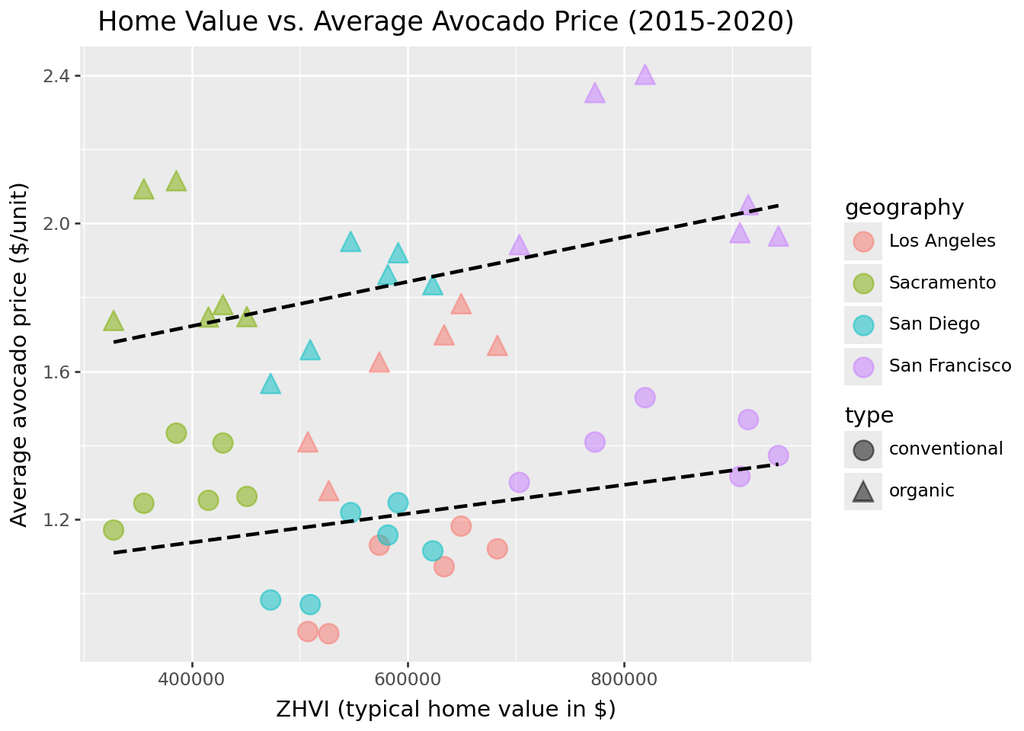

```python
from plotnine import *

(ggplot(joined_data, aes(x="zhvi_usd", y="avg_avocado_price",
                       color="geography", shape="type"))
    + geom_point(size = 5, alpha = 0.50)
    # looked up geom_smooth() arguments and experimented with them
    + geom_smooth(method="lm", se=False, linetype="dashed", color="black")
    + scale_x_continuous()
    + labs(title="Home Value vs. Average Avocado Price (2015-2020)",
           x="ZHVI (typical home value in $)",
           y="Average avocado price ($/unit)")
    + theme()
)
```